# Kodiak Chum Baseline - 2018 Update

```r
knitr::opts_chunk$set(echo = TRUE)
library(tidyverse)
library(lubridate)
library(leaflet)
library(DT)
library(genepop)
library(abind)
bbind <- function(...) { abind(..., along = 3) }
.username <- "krshedd"
.password <- ""
source("~/../R/Functions.GCL.R")
```

# Introduction

## Purpose

This is a quick baseline update to Andy Barclay’s 2015 Kodiak chum baseline. This baseline update includes 3 new collections sampled by ADF&G staff (Birch Foster) in 2017:

1. CMBARL17 - Barling Bay Creek - 9/1/2017
2. CMKIAV17 - Kiavak Portage - 9/1/2017
3. CMNATA17 - Natalia Bay Creek - 9/1/2017

## Background

Andy’s work in late 2015 was done to assess population genetic structure of chum salmon in SE Kodiak, specifically in the Three Saints Bay area. Kodiak Regional Aquaculture Association (KRAA) wanted to establish a new hatchery in Old Harbor to make early-run chum salmon for a remote release site in Three Saints Bay. KRAA intended to use the Sturgeon broodstock, that they already use for their Kitoi Bay facility. ADF&G regional staff indicated that there are known early-run chum stocks in the Three Saints Bay area, which would present a genetic risk to using Sturgeon River broodstock in the area (similar run timing, but potentially genetically different). Regional staff indicated that Barling Bay Creek in particular had early-run chum salmon. Thus, regional staff collected temporal samples throughout the season from Barling Bay Creek and other nearby systems to get a better understanding of population genetic structure in SE Kodiak to determine whether early-run Barling Bay Creek chum were sufficiently distinct from Sturgeon River chum to be an unaccpetable genetic risk. Ultimately, Andy’s work did show that Barling Bay Creek has significant temporal genetic structure throughout the season (July vs. August vs. September). These results resulted in a memo with a department recommendation to use local broodstock (early-run Barling Bay Creek) rather than Sturgeon River broodstock from Kitoi Bay for the Three Saints Bay project.

This 2018 baseline update will incorporate three additional collections made by ADF&G staff. The results from this baseline update are not going to change the decision regarding use of local broodsource, they are intended to provide some additional *pre-hatchery* baseline.

## Outline

This R Notebook will perform the following tasks:

- Read in genotype data
  - Create *LocusControl*
  - Read in all project genotypes
- Map of all baseline collections
- Pooling Barling 2015
  - Split `CMBARLR15` into *early*, *middle*, and *late* collections (as in the 2015 baseline)
- Determine *FailureRate*
- Data QA
  - Removing fish missing >= 20% of genotypes
  - Remove within collection duplicates
  - Save final, post-QA genotypes
- Check *HWE* - collections
- Pooling temporal collections
- Check *HWE* - populations
- Map of all baseline populations
- Explore genetic structure
  - Generate allele frequency plots
  - Fst tree
  - MDS using Fst

# Read in genotype data

Need to create *LocusControl* for the markers we are using and then read in all the genotype data for the same collections that Andy analyzed in 2015 + the three new collections from 2017 (the update).

## Markerset

This analysis is using the 96 SNPs from WASSIP.

```r
CreateLocusControl.GCL(markersuite = "ChumGolden2011_96SNPs", username = .username, password = .password)
```

```
[1] "LocusControl created for markersuite='ChumGolden2011_96SNPs'"
```

```r
loci96 <- LocusControl$locusnames
dir.create("../2018/Objects")
save_objects(c("LocusControl", "loci96"), "../2018/Objects")
```

## Collections

We want to include the same 86 collections used by Andy in his 2015 baseline + the 3 new collections from 2017.

```r
(collections_89 <- read_csv("../2018/collections89.csv") %>%
  pull("silly"))
```

```
 [1] "CHBAL92UW"    "CHLIJ92UW"    "CMLIJ09UW"    "CMBEL92UW"    "CMCAN09UW"    "CMCAN92UW"    "CMCHI09UW"    "CMCHI96UW"
 [9] "CMCOL96UW"    "CMDEL96UW"    "CMFOST09UW"   "CMRUB96UW"    "CMRUS09UW"    "CMRUS92UW"    "CMRUS93UW"    "CMSANC09UW"
[17] "CMSANC96UW"   "CMSMOKH10"    "CMSTE09UW"    "CMSTE92UW"    "CMSTEPR09UW"  "CMWESM93UW"   "CMVOL09UW"    "CMVOL92UW"
[25] "CMVOL96UW"    "CMZAC92UW"    "CMWESN93UW"   "CMAMBM09UW"   "CMCHIGK09UW"  "CMWESI93UW"   "CMIVAN09UW"   "CMWESL93UW"
[33] "CMWESK93UW"   "CMKUJUNF09UW" "CMNAKIL08UW"  "CMNECR08UW"   "CMOCEB09UW"   "CMPORTC08UW"  "CMWESJ93UW"   "CMRUDY10"
[41] "CMWESE93UW"   "CMWESD93UW"   "CMBEARBC09UW" "CMWESH93UW"   "CMBIGRI09UW"  "CMDRYBR09UW"  "CMWESF93UW"   "CMKIAL09UW"
[49] "CMPASS09UW"   "CMWESG93UW"   "CHAME92UW"    "CHDOG92UW"    "CHKIZ92UW"    "CMKIZH09UW"   "CHUGA92UW"    "CMUGAN09UW"
[57] "CMBARL09UW"   "CMBARLR15"    "CMBSU92UW"    "CMBSUK09UW"   "CMCOXC09UW"   "CMDEAD09UW"   "CMDOGSC10"    "CMEAGLH09UW"
[65] "CMWESP93UW"   "CMGULLC09UW"  "CMKARL09UW"   "CMWESA93UW"   "CMKITB09UW"   "CMPAUL15"     "CMMIDWAY15"   "CMHIDDB15"
[73] "CMKAIUG15"    "CMOLDS10"     "CMPORTNE09UW" "CMROUGH09UW"  "CMRUSSI07UW"  "CMRUSSI09UW"  "CMSITKI09UW"  "CMSPIRU09UW"
[81] "CMSTU08UW"    "CMSTU09UW"    "CMSTU92"      "CMWKIL08UW"   "CMWKIL09UW"   "CMZACR09UW"   "CMBARL17"     "CMKIAV17"
[89] "CMNATA17"
```

```r
save_objects("collections_89", "../2018/Objects/")
```

Read in genotype data from LOKI.

```r
LOKI2R.GCL(sillyvec = collections_89, username = .username, password = .password)
```

```
CHBAL92UW.gcl created 1 of 89 completed.
CHLIJ92UW.gcl created 2 of 89 completed.
CMLIJ09UW.gcl created 3 of 89 completed.
CMBEL92UW.gcl created 4 of 89 completed.
CMCAN09UW.gcl created 5 of 89 completed.
CMCAN92UW.gcl created 6 of 89 completed.
CMCHI09UW.gcl created 7 of 89 completed.
CMCHI96UW.gcl created 8 of 89 completed.
CMCOL96UW.gcl created 9 of 89 completed.
CMDEL96UW.gcl created 10 of 89 completed.
CMFOST09UW.gcl created 11 of 89 completed.
CMRUB96UW.gcl created 12 of 89 completed.
CMRUS09UW.gcl created 13 of 89 completed.
CMRUS92UW.gcl created 14 of 89 completed.
CMRUS93UW.gcl created 15 of 89 completed.
CMSANC09UW.gcl created 16 of 89 completed.
CMSANC96UW.gcl created 17 of 89 completed.
CMSMOKH10.gcl created 18 of 89 completed.
CMSTE09UW.gcl created 19 of 89 completed.
CMSTE92UW.gcl created 20 of 89 completed.
CMSTEPR09UW.gcl created 21 of 89 completed.
CMWESM93UW.gcl created 22 of 89 completed.
CMVOL09UW.gcl created 23 of 89 completed.
CMVOL92UW.gcl created 24 of 89 completed.
CMVOL96UW.gcl created 25 of 89 completed.
CMZAC92UW.gcl created 26 of 89 completed.
CMWESN93UW.gcl created 27 of 89 completed.
CMAMBM09UW.gcl created 28 of 89 completed.
CMCHIGK09UW.gcl created 29 of 89 completed.
CMWESI93UW.gcl created 30 of 89 completed.
CMIVAN09UW.gcl created 31 of 89 completed.
CMWESL93UW.gcl created 32 of 89 completed.
CMWESK93UW.gcl created 33 of 89 completed.
CMKUJUNF09UW.gcl created 34 of 89 completed.
CMNAKIL08UW.gcl created 35 of 89 completed.
CMNECR08UW.gcl created 36 of 89 completed.
CMOCEB09UW.gcl created 37 of 89 completed.
CMPORTC08UW.gcl created 38 of 89 completed.
CMWESJ93UW.gcl created 39 of 89 completed.
CMRUDY10.gcl created 40 of 89 completed.
```

[output cut: 34 more lines]

```
CMPORTNE09UW.gcl created 75 of 89 completed.
CMROUGH09UW.gcl created 76 of 89 completed.
CMRUSSI07UW.gcl created 77 of 89 completed.
CMRUSSI09UW.gcl created 78 of 89 completed.
CMSITKI09UW.gcl created 79 of 89 completed.
CMSPIRU09UW.gcl created 80 of 89 completed.
CMSTU08UW.gcl created 81 of 89 completed.
CMSTU09UW.gcl created 82 of 89 completed.
CMSTU92.gcl created 83 of 89 completed.
CMWKIL08UW.gcl created 84 of 89 completed.
CMWKIL09UW.gcl created 85 of 89 completed.
CMZACR09UW.gcl created 86 of 89 completed.
CMBARL17.gcl created 87 of 89 completed.
CMKIAV17.gcl created 88 of 89 completed.
CMNATA17.gcl created 89 of 89 completed.
```

```
Time difference of 2.289525 mins
Time difference of 2.289525 mins
```

```r
rm(.username, .password)
dir.create("../2018/Genotypes")
dir.create("../2018/Genotypes/original")
save_sillys(collections_89, "../2018/Genotypes/original")
```

# Map of all baseline collections

Pull the latitude/longitude data for `collections_89` from OceanAK, need to remove “UW” from all sillys for filtering to get the report.

```r
writeClipboard(paste(str_replace(collections_89, "UW", ""), collapse = ";"))
dir.create("../2018/OceanAK")
```

Create a map of the baseline collections

```r
read_csv("../2018/OceanAK/collections_89_Just the Lat_Longs.csv") %>%
  leaflet(width = "100%") %>%
  addTiles() %>%
  addMarkers(~ Longitude, ~ Latitude, label = ~ `Silly Code`, clusterOptions = markerClusterOptions())
```

[interactive chart not shown]

Create an awesome map of the baseline collections

```r
collections_89_info <- read_csv("../2018/OceanAK/collections_89_Collection Info_mod.csv")
collections_89_info %>%
  count(Quadrant)
```

| Quadrant | n |
| --- | --- |
| Chignik | 15 |
| Kodiak Mainland | 9 |
| Kodiak/Afognak Islands | 39 |
| Peninsula - South | 26 |

```r
collections_89_info <- collections_89_info %>%
  mutate(color = case_when(Quadrant == "Peninsula - South" ~ "red",
                           Quadrant == "Chignik" ~ "orange",
                           Quadrant == "Kodiak Mainland" ~ "blue",
                           Quadrant == "Kodiak/Afognak Islands" ~ "purple"))
icons <- awesomeIcons(icon = 'ios-close', iconColor = 'black', library = 'ion', markerColor = collections_89_info$color)
collections_89_info %>%
  leaflet(width = "100%") %>%
  addTiles() %>%
  addAwesomeMarkers(~ Longitude, ~ Latitude, icon = icons, label = ~ `Silly Code`)
```

[interactive chart not shown]

# Pooling Barling 2015

We need to split `CMBARLR15` into *early*, *middle*, and *late* collections (as in the 2015 baseline), as this *silly* represents 3 distinct collections.

```r
table(CMBARLR15.gcl$attributes$CAPTURE_DATE)
```

```
2015-07-09 2015-08-03 2015-09-11
       104        104         88
```

Use `AttributesToIDs.GCL` to split by date and pool into new silly’s.

```r
# early
CMBARLR15_early_ids <- AttributesToIDs.GCL(silly = "CMBARLR15", attribute = "CAPTURE_DATE", matching = "2015-07-09")
PoolCollections.GCL(collections = "CMBARLR15", loci = loci96, IDs = list(CMBARLR15 = CMBARLR15_early_ids), newname = "CMBARLR15E")
```

```r
# middle
CMBARLR15_middle_ids <- AttributesToIDs.GCL(silly = "CMBARLR15", attribute = "CAPTURE_DATE", matching = "2015-08-03")
PoolCollections.GCL(collections = "CMBARLR15", loci = loci96, IDs = list(CMBARLR15 = CMBARLR15_middle_ids), newname = "CMBARLR15M")
```

```r
# late
CMBARLR15_late_ids <- AttributesToIDs.GCL(silly = "CMBARLR15", attribute = "CAPTURE_DATE", matching = "2015-09-11")
PoolCollections.GCL(collections = "CMBARLR15", loci = loci96, IDs = list(CMBARLR15 = CMBARLR15_late_ids), newname = "CMBARLR15L")
```

```r
save_sillys(c("CMBARLR15E", "CMBARLR15M", "CMBARLR15L"), "../2018/Genotypes/original/")
```

Now create a new *sillyvec* with the three temporal 2015 Barling collections split out and the original `CMBARLR15` removed. Planning to sort for ease of use.

```r
(collections_91 <- sort(c(collections_89[collections_89 != "CMBARLR15"], "CMBARLR15E", "CMBARLR15M", "CMBARLR15L")))
```

```
 [1] "CHAME92UW"    "CHBAL92UW"    "CHDOG92UW"    "CHKIZ92UW"    "CHLIJ92UW"    "CHUGA92UW"    "CMAMBM09UW"   "CMBARL09UW"
 [9] "CMBARL17"     "CMBARLR15E"   "CMBARLR15L"   "CMBARLR15M"   "CMBEARBC09UW" "CMBEL92UW"    "CMBIGRI09UW"  "CMBSU92UW"
[17] "CMBSUK09UW"   "CMCAN09UW"    "CMCAN92UW"    "CMCHI09UW"    "CMCHI96UW"    "CMCHIGK09UW"  "CMCOL96UW"    "CMCOXC09UW"
[25] "CMDEAD09UW"   "CMDEL96UW"    "CMDOGSC10"    "CMDRYBR09UW"  "CMEAGLH09UW"  "CMFOST09UW"   "CMGULLC09UW"  "CMHIDDB15"
[33] "CMIVAN09UW"   "CMKAIUG15"    "CMKARL09UW"   "CMKIAL09UW"   "CMKIAV17"     "CMKITB09UW"   "CMKIZH09UW"   "CMKUJUNF09UW"
[41] "CMLIJ09UW"    "CMMIDWAY15"   "CMNAKIL08UW"  "CMNATA17"     "CMNECR08UW"   "CMOCEB09UW"   "CMOLDS10"     "CMPASS09UW"
[49] "CMPAUL15"     "CMPORTC08UW"  "CMPORTNE09UW" "CMROUGH09UW"  "CMRUB96UW"    "CMRUDY10"     "CMRUS09UW"    "CMRUS92UW"
[57] "CMRUS93UW"    "CMRUSSI07UW"  "CMRUSSI09UW"  "CMSANC09UW"   "CMSANC96UW"   "CMSITKI09UW"  "CMSMOKH10"    "CMSPIRU09UW"
[65] "CMSTE09UW"    "CMSTE92UW"    "CMSTEPR09UW"  "CMSTU08UW"    "CMSTU09UW"    "CMSTU92"      "CMUGAN09UW"   "CMVOL09UW"
[73] "CMVOL92UW"    "CMVOL96UW"    "CMWESA93UW"   "CMWESD93UW"   "CMWESE93UW"   "CMWESF93UW"   "CMWESG93UW"   "CMWESH93UW"
[81] "CMWESI93UW"   "CMWESJ93UW"   "CMWESK93UW"   "CMWESL93UW"   "CMWESM93UW"   "CMWESN93UW"   "CMWESP93UW"   "CMWKIL08UW"
[89] "CMWKIL09UW"   "CMZAC92UW"    "CMZACR09UW"
```

```r
save_objects("collections_91", "../2018/Objects/")
```

Save sillys post split.

```r
dir.create("../2018/Genotypes/original_split")
save_sillys(collections_91, "../2018/Genotypes/original_split")
```

# Determine *FailureRate*

| silly | fail |
| --- | --- |
| CMKITB09UW | 0.5427495875 |
| CMSTU09UW | 0.1759166667 |
| CMROUGH09UW | 0.1731359649 |
| CMNECR08UW | 0.1625744048 |
| CMUGAN09UW | 0.1496710526 |
| CMNAKIL08UW | 0.1139018692 |
| CMKARL09UW | 0.0793269231 |
| CMBARLR15 | 0.0687288851 |
| CMSPIRU09UW | 0.0635964912 |
| CMWESF93UW | 0.0625000000 |

[output cut: 79 more lines]

| locus | fail |
| --- | --- |
| Oke_U504-228 | 0.04272249 |
| Oke_CKS-389 | 0.04235525 |
| Oke_Tf-278 | 0.04162076 |
| Oke_U302-195 | 0.04113111 |
| Oke_GPH-105 | 0.04100869 |
| Oke_U507-286 | 0.04051904 |
| Oke_Cr30 | 0.04039662 |
| Oke_U506-110 | 0.03978455 |
| Oke_HP-182 | 0.03917248 |
| Oke_U509-219 | 0.03843800 |

[output cut: 86 more lines]

| plate | fail |
| --- | --- |
| 57797 | 0.1018395390 |
| 57798 | 0.0700657895 |
| 57799 | 0.0666307471 |
| NA | 0.0436777527 |
| 57789 | 0.0167763158 |
| 57790 | 0.0155701754 |
| 13273 | 0.0103070175 |
| 57796 | 0.0087719298 |
| 13337 | 0.0083333333 |
| 57793 | 0.0052631579 |

[output cut: 9 more lines]

| project | fail |
| --- | --- |
| westward_chum_baseline | NA |

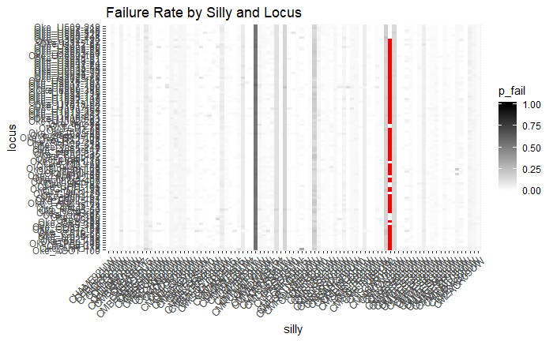

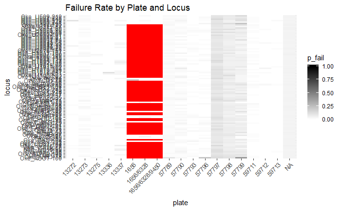

```r
project <- "westward_chum_baseline"
loci <- loci96
(failure_rate <- FailureRate.GCL(sillyvec = collections_91))
```

```r
failure_rate_noplots <- failure_rate[1:4]
save_objects("failure_rate_noplots", "../2018/Objects/")
```

Also calculate sample size by locus and save.

```r
(sample_size_by_locus <- SampSizeByLocus.GCL(sillyvec = collections_91, loci = loci96) %>%
  as_tibble(rownames = "silly"))
```

| silly | Oke_ACOT.100 | Oke_AhR1.78 | Oke_arf.319 | Oke_ATP5L.105 | Oke_azin1.90 | Oke_brd2.118 | Oke_brp16.65 | Oke_CATB.60 | Oke_ccd16.77 | Oke_CD81.108 | Oke_CD81.173 | Oke_CKS.389 | Oke_CKS1.94 | Oke_Cr30 | Oke_Cr386 | Oke_ctgf.105 | Oke_DCXR.87 | Oke_e2ig5.50 | Oke_eif4g1.43 | Oke_f5.71 | Oke_FANK1.166 | Oke_FBXL5.61 | Oke_gdh1.191 | Oke_gdh1.62 | Oke_GHII.3129 | Oke_glrx1.78 | Oke_GPDH.191 | Oke_GPH.105 | Oke_HP.182 | … |
| --- | --- | --- | --- | --- | --- | --- | --- | --- | --- | --- | --- | --- | --- | --- | --- | --- | --- | --- | --- | --- | --- | --- | --- | --- | --- | --- | --- | --- | --- | --- |
| CHAME92UW | 95 | 95 | 95 | 95 | 95 | 95 | 95 | 95 | 95 | 95 | 95 | 95 | 95 | 95 | 95 | 94 | 95 | 95 | 95 | 95 | 95 | 95 | 93 | 95 | 94 | 95 | 94 | 95 | 95 | … |
| CHBAL92UW | 93 | 92 | 93 | 92 | 92 | 93 | 93 | 93 | 92 | 93 | 93 | 92 | 93 | 93 | 93 | 93 | 93 | 93 | 93 | 93 | 93 | 93 | 93 | 93 | 92 | 93 | 93 | 92 | 92 | … |
| CHDOG92UW | 94 | 94 | 93 | 94 | 95 | 95 | 95 | 95 | 95 | 94 | 95 | 95 | 95 | 95 | 94 | 94 | 95 | 95 | 95 | 95 | 95 | 95 | 93 | 95 | 95 | 95 | 95 | 95 | 95 | … |
| CHKIZ92UW | 84 | 84 | 84 | 84 | 84 | 84 | 84 | 84 | 78 | 84 | 83 | 84 | 84 | 84 | 84 | 84 | 84 | 84 | 84 | 84 | 84 | 84 | 84 | 84 | 84 | 84 | 84 | 84 | 84 | … |
| CHLIJ92UW | 80 | 80 | 80 | 80 | 80 | 80 | 79 | 80 | 80 | 79 | 80 | 80 | 80 | 80 | 80 | 80 | 79 | 80 | 80 | 80 | 80 | 80 | 80 | 80 | 79 | 79 | 80 | 80 | 80 | … |
| CHUGA92UW | 94 | 93 | 94 | 94 | 94 | 94 | 94 | 94 | 92 | 94 | 94 | 94 | 94 | 94 | 94 | 94 | 94 | 93 | 94 | 93 | 94 | 94 | 94 | 94 | 94 | 93 | 93 | 94 | 94 | … |
| CMAMBM09UW | 85 | 85 | 85 | 85 | 85 | 85 | 85 | 85 | 82 | 85 | 85 | 85 | 85 | 85 | 85 | 85 | 85 | 85 | 85 | 85 | 85 | 85 | 85 | 84 | 85 | 85 | 85 | 84 | 85 | … |
| CMBARL09UW | 92 | 90 | 93 | 93 | 93 | 93 | 93 | 91 | 92 | 93 | 92 | 93 | 92 | 92 | 93 | 92 | 92 | 93 | 93 | 91 | 92 | 93 | 93 | 93 | 93 | 93 | 92 | 92 | 91 | … |
| CMBARL17 | 94 | 94 | 95 | 95 | 95 | 95 | 95 | 95 | 95 | 95 | 95 | 94 | 94 | 95 | 94 | 94 | 94 | 95 | 95 | 95 | 95 | 95 | 95 | 94 | 95 | 95 | 95 | 95 | 95 | … |
| CMBARLR15E | 88 | 96 | 96 | 97 | 95 | 96 | 97 | 99 | 95 | 99 | 97 | 96 | 98 | 98 | 98 | 98 | 97 | 98 | 97 | 95 | 98 | 96 | 97 | 96 | 99 | 98 | 97 | 94 | 97 | … |

[output cut: 81 more lines]

```r
dir.create("../2018/Tables")
write_csv(sample_size_by_locus, "../2018/Tables/sample_size_by_locus.csv")
```

# Data QA

Perform standard data QA processes to filter out untrustworth genotypes.

```r
sample_size_qa <- tibble(silly = collections_91) %>%
  mutate(genotyped = sapply(silly, function(x) get(paste0(x, ".gcl"))$n))
```

## Missing

Remove individuals missing >=20% of genotypes (i.e. the 80% rule).

```r
miss_loci <- RemoveIndMissLoci.GCL(sillyvec = collections_91, proportion = 0.8)
save_objects("miss_loci", "../2018/Objects/")
# show individuals removed
miss_loci[miss_loci != "None"]
```

```
$`CHBAL92UW`
[1] "10" "22"

$CHKIZ92UW
[1] "48" "54" "64" "81"

$CHUGA92UW
[1] "60"

$CMBARL09UW
[1] "92" "95"

$CMBARL17
[1] "63"

$CMBARLR15E
[1] "50" "56" "59" "61" "62" "77"

$CMBARLR15L
 [1] "3"  "16" "17" "19" "20" "42" "46" "61" "76" "85"

$CMBARLR15M
[1] "26" "28"

$CMBEARBC09UW
[1] "66" "84"

$CMCAN09UW
[1] "58" "64" "71"

$CMCAN92UW
[1] "93"

$CMCHI09UW
[1] "16" "52" "95"

$CMCHI96UW
[1] "19" "29" "54"

$CMCHIGK09UW
```

[output cut: 126 more lines]

```

$CMWESN93UW
[1] "23" "36"

$CMWESP93UW
[1] "17" "37" "46"

$CMWKIL09UW
[1] "34" "42" "59" "70"

$CMZAC92UW
[1] "68" "71" "74"

$CMZACR09UW
[1] "37"
```

```r
sample_size_qa <- sample_size_qa %>%
  mutate(missing = genotyped - sapply(silly, function(x) get(paste0(x, ".gcl"))$n))
```

## Duplicate

Remove duplicate individuals within the same collection. Typically we specify *duplicates* as a pair of individuals that share >=95% of genotypes. Once a pair of *duplicates* is identified, we keep the individual with the most genotypes and remove the other.

```r
duplicate_check_95 <- CheckDupWithinSilly.GCL(sillyvec = collections_91, loci = loci96, quantile = NULL, minproportion = 0.95)
duplicate_summary <- sapply(collections_91, function(x) duplicate_check_95[[x]]$report, simplify = FALSE)
duplicate_remove <- RemoveDups.GCL(duplicate_check_95)
save_objects(c("duplicate_summary", "duplicate_remove"), "../2018/Objects/")
# show individuals removed
duplicate_remove[duplicate_remove != "Nothing Removed"]
```

```
$`CMBARLR15E`
[1] "87"  "21"  "100" "13"

$CMBEARBC09UW
[1] "38"

$CMBSUK09UW
[1] "36"

$CMCHI09UW
[1] "19" "34" "44"

$CMCHI96UW
[1] "7"

$CMCHIGK09UW
[1] "48"

$CMCOXC09UW
[1] "23"

$CMEAGLH09UW
[1] "30"

$CMIVAN09UW
[1] "5"

$CMKARL09UW
[1] "80"

$CMKIAL09UW
[1] "11"

$CMKIAV17
[1] "30"

$CMKIZH09UW
[1] "58"

$CMOLDS10
[1] "38" "80"

$CMRUSSI07UW
[1] "14"

$CMSANC96UW
[1] "49" "36"

$CMSTE09UW
[1] "32"

$CMWESN93UW
[1] "10"

$CMZAC92UW
[1] "13"
```

```r
sample_size_qa <- sample_size_qa %>%
  mutate(duplicate = genotyped - missing - sapply(silly, function(x) get(paste0(x, ".gcl"))$n))
```

## Final

How many fish did we end up with in our final baseline? Save final genotypes.

```r
(sample_size_qa <- sample_size_qa %>%
  mutate(final = sapply(silly, function(x) get(paste0(x, ".gcl"))$n)))
```

| silly | genotyped | missing | duplicate | final |
| --- | --- | --- | --- | --- |
| CHAME92UW | 95 | 0 | 0 | 95 |
| CHBAL92UW | 95 | 2 | 0 | 93 |
| CHDOG92UW | 95 | 0 | 0 | 95 |
| CHKIZ92UW | 88 | 4 | 0 | 84 |
| CHLIJ92UW | 80 | 0 | 0 | 80 |
| CHUGA92UW | 95 | 1 | 0 | 94 |
| CMAMBM09UW | 85 | 0 | 0 | 85 |
| CMBARL09UW | 95 | 2 | 0 | 93 |
| CMBARL17 | 95 | 1 | 0 | 94 |
| CMBARLR15E | 104 | 6 | 4 | 94 |

[output cut: 81 more lines]

```r
write_csv(sample_size_qa, "../2018/Tables/sample_size_qa.csv")
dir.create("../2018/Genotypes/original_split_postQA/")
save_sillys(collections_91, "../2018/Genotypes/original_split_postQA/")
```

What is smallest collection?

| silly | genotyped | missing | duplicate | final |
| --- | --- | --- | --- | --- |
| CMSTU92 | 71 | 71 | 0 | 0 |
| CMWKIL08UW | 4 | 0 | 0 | 4 |
| CMSTU08UW | 6 | 0 | 0 | 6 |
| CMVOL96UW | 42 | 1 | 0 | 41 |
| CMPAUL15 | 46 | 1 | 0 | 45 |
| CMSTE92UW | 50 | 0 | 0 | 50 |
| CMVOL92UW | 53 | 0 | 0 | 53 |
| CMDOGSC10 | 65 | 0 | 0 | 65 |
| CMZACR09UW | 67 | 1 | 0 | 66 |
| CMWESI93UW | 70 | 1 | 0 | 69 |

[output cut: 81 more lines]

Whoa, we should totally junk some of these collections given their low sample size (or complete lack of fish!). We’ll keep anything with at least 40 fish.

```r
(collections_88 <- sample_size_qa %>%
   filter(final > 40) %>%
   pull("silly"))
```

```
 [1] "CHAME92UW"    "CHBAL92UW"    "CHDOG92UW"    "CHKIZ92UW"    "CHLIJ92UW"    "CHUGA92UW"    "CMAMBM09UW"   "CMBARL09UW"
 [9] "CMBARL17"     "CMBARLR15E"   "CMBARLR15L"   "CMBARLR15M"   "CMBEARBC09UW" "CMBEL92UW"    "CMBIGRI09UW"  "CMBSU92UW"
[17] "CMBSUK09UW"   "CMCAN09UW"    "CMCAN92UW"    "CMCHI09UW"    "CMCHI96UW"    "CMCHIGK09UW"  "CMCOL96UW"    "CMCOXC09UW"
[25] "CMDEAD09UW"   "CMDEL96UW"    "CMDOGSC10"    "CMDRYBR09UW"  "CMEAGLH09UW"  "CMFOST09UW"   "CMGULLC09UW"  "CMHIDDB15"
[33] "CMIVAN09UW"   "CMKAIUG15"    "CMKARL09UW"   "CMKIAL09UW"   "CMKIAV17"     "CMKITB09UW"   "CMKIZH09UW"   "CMKUJUNF09UW"
[41] "CMLIJ09UW"    "CMMIDWAY15"   "CMNAKIL08UW"  "CMNATA17"     "CMNECR08UW"   "CMOCEB09UW"   "CMOLDS10"     "CMPASS09UW"
[49] "CMPAUL15"     "CMPORTC08UW"  "CMPORTNE09UW" "CMROUGH09UW"  "CMRUB96UW"    "CMRUDY10"     "CMRUS09UW"    "CMRUS92UW"
[57] "CMRUS93UW"    "CMRUSSI07UW"  "CMRUSSI09UW"  "CMSANC09UW"   "CMSANC96UW"   "CMSITKI09UW"  "CMSMOKH10"    "CMSPIRU09UW"
[65] "CMSTE09UW"    "CMSTE92UW"    "CMSTEPR09UW"  "CMSTU09UW"    "CMUGAN09UW"   "CMVOL09UW"    "CMVOL92UW"    "CMVOL96UW"
[73] "CMWESA93UW"   "CMWESD93UW"   "CMWESE93UW"   "CMWESF93UW"   "CMWESG93UW"   "CMWESH93UW"   "CMWESI93UW"   "CMWESJ93UW"
[81] "CMWESK93UW"   "CMWESL93UW"   "CMWESM93UW"   "CMWESN93UW"   "CMWESP93UW"   "CMWKIL09UW"   "CMZAC92UW"    "CMZACR09UW"
```

```r
save_objects("collections_88", "../2018/Objects/")
```

# Check *HWE* - collections

Write out a *Genepop* file to check HWE within collections.

```r
dir.create("../2018/Genepop")
gcl2Genepop.GCL(sillyvec = collections_88, loci = loci96, path = "../2018/Genepop/collections_88.gen", VialNums = TRUE)
```

Calculate HWE using the *genepop* package [link](https://cran.r-project.org/web/packages/genepop/index.html).

```r
test_HW(inputFile = "../2018/Genepop/collections_88.gen", outputFile = "../2018/Genepop/collections_88.P.txt")
```

```
Dangerous input file name extension:
   the genepop code expects either extension '.txt' or no extension.
```

[output not shown]

## Summary table

Read in results and save summary HWE p-values.

```r
hwe_collections_88 <- ReadGenepopHWE.GCL(file = "../2018/Genepop/collections_88.txt.P", sillyvec = collections_88)
```

```
Read 18222 items
```

```
All p-values are pulled directly from the Genepop *.P file if calculated via Exact test.
If calculated via MCMC then over all loci/pops are derived in this function, correcting p = 0 for the number of batches * iterations!
NA in 'smmry' dataframe means that locus in either 1) monomorphic (or very low MAF) or 2) not diploid (haploid mtSNP).
Haploid loci are not included in the 'HWdata' data.frame.NULL
```

```r
(hwe_summary_collections_88 <- hwe_collections_88$SummaryPValues %>%
  as_tibble(rownames = "locus"))
```

| locus | CHAME92UW | CHBAL92UW | CHDOG92UW | CHKIZ92UW | CHLIJ92UW | CHUGA92UW | CMAMBM09UW | CMBARL09UW | CMBARL17 | CMBARLR15E | CMBARLR15L | CMBARLR15M | CMBEARBC09UW | CMBEL92UW | CMBIGRI09UW | CMBSU92UW | CMBSUK09UW | CMCAN09UW | CMCAN92UW | CMCHI09UW | CMCHI96UW | CMCHIGK09UW | CMCOL96UW | CMCOXC09UW | CMDEAD09UW | CMDEL96UW | CMDOGSC10 | CMDRYBR09UW | CMEAGLH09UW | … |
| --- | --- | --- | --- | --- | --- | --- | --- | --- | --- | --- | --- | --- | --- | --- | --- | --- | --- | --- | --- | --- | --- | --- | --- | --- | --- | --- | --- | --- | --- | --- |
| Oke_ACOT-100 | 0.1905 | 0.4844 | 0.8301 | 0.6473 | 0.8113 | 0.8243 | 0.2782 | 0.6597 | 0.5235 | 0.6596 | 0.3658 | 1.0000 | 0.6420 | 0.3916 | 0.0154 | 0.4067 | 0.3362 | 0.3585 | 0.0690 | 0.5455 | 1.0000 | 0.4926 | 0.2738 | 1.0000 | 0.0131 | 0.1554 | 1.0000 | 0.2264 | 0.6647 | … |
| Oke_AhR1-78 | 0.6855 | 0.5239 | 0.5366 | 1.0000 | 1.0000 | 0.6587 | 0.1348 | 1.0000 | 0.2909 | 0.8342 | 0.4898 | 0.5362 | 1.0000 | 0.8256 | 0.8370 | 0.2393 | 0.2930 | 1.0000 | 0.1350 | 0.3975 | 0.2075 | 0.6718 | 1.0000 | 0.2054 | 0.8364 | 0.8364 | 0.7921 | 1.0000 | 0.4096 | … |
| Oke_arf-319 | 0.6460 | 1.0000 | 0.2007 | 1.0000 | 0.2114 | 0.7520 | 0.0620 | 0.4649 | 1.0000 | 0.2205 | 0.6067 | 0.8154 | 1.0000 | 0.1831 | 0.6409 | 0.0424 | 0.5088 | 1.0000 | 0.1058 | 0.6308 | 0.0339 | 1.0000 | 0.0820 | 1.0000 | 0.6402 | 0.1627 | 0.7985 | 0.7951 | 1.0000 | … |
| Oke_ATP5L-105 | 0.6433 | 0.3846 | 0.5189 | 0.6566 | 0.1064 | 0.6569 | 0.8202 | 0.2709 | 0.3893 | 0.8348 | 0.2231 | 0.8355 | 1.0000 | 0.2203 | 0.6579 | 0.6846 | 0.2971 | 1.0000 | 0.4706 | 0.1022 | 0.3377 | 0.6691 | 1.0000 | 0.3741 | 0.6625 | 0.1674 | 1.0000 | 0.6094 | 0.6678 | … |
| Oke_azin1-90 | 0.0818 | 0.8030 | 0.3339 | 0.1040 | 0.2970 | 1.0000 | 0.4890 | 0.8121 | 0.4144 | 1.0000 | 0.3058 | 0.4936 | 1.0000 | 0.0185 | 0.1812 | 1.0000 | 0.6014 | 0.6068 | 1.0000 | 0.1707 | 1.0000 | 0.3588 | 0.4066 | 0.7525 | 0.1799 | 0.8095 | 0.2931 | 0.5802 | 0.6575 | … |
| Oke_brd2-118 | 1.0000 | 1.0000 | 0.3825 | 1.0000 | 1.0000 | 0.2885 | 0.6106 | 0.1004 | 0.5492 | 0.5418 | 0.1305 | 0.4364 | 0.7722 | 0.7782 | 0.7847 | 1.0000 | 0.1094 | 0.0302 | 0.5502 | 0.0363 | 0.7917 | 1.0000 | 0.0661 | 0.5731 | 0.7844 | 0.2614 | 0.4568 | 1.0000 | 0.3890 | … |
| Oke_brp16-65 | 0.4079 | 0.0326 | 0.3710 | 0.8297 | 0.6519 | 0.3914 | 0.5175 | 0.3998 | 0.6822 | 0.8281 | 0.0118 | 1.0000 | 0.0211 | 0.3822 | 0.4153 | 0.0651 | 0.5289 | 1.0000 | 0.6736 | 0.3858 | 0.8365 | 0.3776 | 0.4159 | 0.8326 | 0.4046 | 0.3055 | 0.0568 | 0.8027 | 0.5310 | … |
| Oke_CATB-60 | 1.0000 | 0.4087 | 1.0000 | 0.3973 | 1.0000 | 0.2195 | 1.0000 | 0.1613 | 1.0000 | 0.4552 | 1.0000 | 1.0000 | 1.0000 | 1.0000 | 0.1804 | NA | NA | 1.0000 | 0.1267 | 0.3758 | 0.0533 | 1.0000 | 0.4528 | 0.2823 | 0.1804 | 1.0000 | 1.0000 | 1.0000 | 1.0000 | … |
| Oke_ccd16-77 | 1.0000 | 0.1317 | 0.8369 | 0.8176 | 0.1760 | 0.1387 | 0.0238 | 0.8297 | 0.5375 | 0.8229 | 0.8143 | 0.2238 | 0.3808 | 0.8089 | 0.8331 | 0.3041 | 0.6479 | 0.8350 | 0.5283 | 0.8387 | 0.5262 | 0.6595 | 0.8264 | 0.6334 | 0.8365 | 0.1062 | 0.6182 | 0.2795 | 0.1263 | … |
| Oke_CD81-108 | 1.0000 | 1.0000 | 0.5107 | 0.3476 | 1.0000 | 1.0000 | 1.0000 | 0.3739 | 0.0828 | 0.1330 | 0.3353 | 0.2220 | 0.6672 | 0.6864 | 0.1528 | 1.0000 | 0.1344 | 0.1183 | 1.0000 | 0.2233 | 1.0000 | 1.0000 | 1.0000 | 0.1507 | 0.1529 | 0.6865 | 1.0000 | 1.0000 | 0.2238 | … |

[output cut: 87 more lines]

```r
write_csv(x = hwe_summary_collections_88, "../2018/Tables/hwe_summary_collections_88.csv")
```

### Collections out of HWP

What do overall-loci p-values look like for collections?

| locus | silly | p |
| --- | --- | --- |
| Overall Loci | CMBARLR15L | 0.1972 |
| Overall Loci | CMIVAN09UW | 0.3956 |
| Overall Loci | CMWESL93UW | 0.4769 |
| Overall Loci | CMBEARBC09UW | 0.4924 |
| Overall Loci | CMEAGLH09UW | 0.5312 |
| Overall Loci | CMCAN92UW | 0.5991 |
| Overall Loci | CMSTEPR09UW | 0.6031 |
| Overall Loci | CMSITKI09UW | 0.6745 |
| Overall Loci | CMKITB09UW | 0.7486 |
| Overall Loci | CMMIDWAY15 | 0.7532 |

[output cut: 79 more lines]

All look pretty good with the potential exception of `CMBARLR15L`.

### Loci out of HWP

What do overall-loci p-values look like for loci?

| locus | silly | p |
| --- | --- | --- |
| Oke_ras1-249 | Overall Pops | 0.0834 |
| Oke_U506-110 | Overall Pops | 0.0979 |
| Oke_U2041-84 | Overall Pops | 0.1776 |
| Oke_CD81-173 | Overall Pops | 0.2905 |
| Oke_eif4g1-43 | Overall Pops | 0.3118 |
| Oke_serpin-140 | Overall Pops | 0.4352 |
| Oke_U1022-139 | Overall Pops | 0.4656 |
| Oke_U1021-102 | Overall Pops | 0.4676 |
| Oke_ccd16-77 | Overall Pops | 0.4748 |
| Oke_Tf-278 | Overall Pops | 0.4905 |

[output cut: 87 more lines]

There are a couple of loci that are suspect.

## HWP plots

Per Waples 2014, we will plot a histogram of HWP p-values to look for collections/loci that do not conform to HWP. We will limit our search to the specific collection and loci that were suspicious.

### Collection

Plot p-values per locus for `CMBARLR15L`

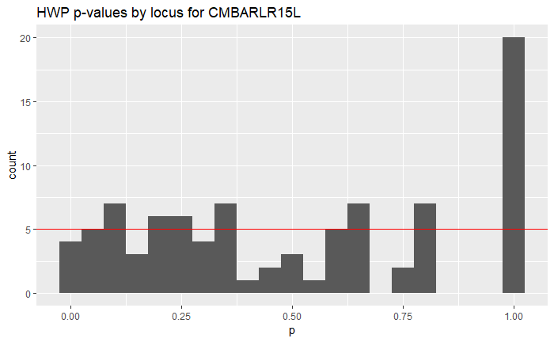

```r
hwe_summary_collections_88 %>%
  gather(silly, p, -locus) %>%
  filter(silly == "CMBARLR15L") %>%
  filter(locus != "Overall Loci") %>%
  ggplot(aes(p)) +
  geom_histogram(binwidth = 0.05) +
  geom_hline(yintercept = 5, colour = "red") +
  ggtitle("HWP p-values by locus for CMBARLR15L")
```

Looks fine, no major cause for concern, now on to plotting for loci.

### Loci

Plot p-values per collection for loci with overall pops p-value < 0.2.

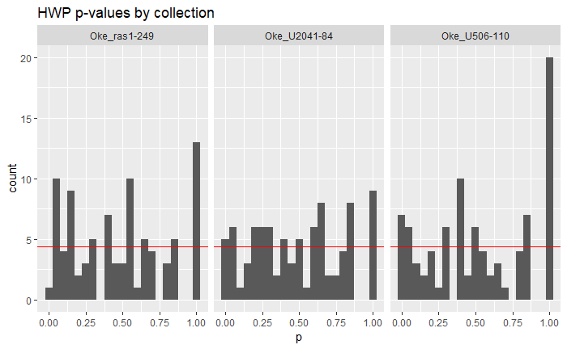

```r
# filter for loci with overall pops < 0.2
hwe_loci_plot <- hwe_summary_collections_88 %>%
  gather(silly, p, -locus) %>%
  filter(silly == "Overall Pops" & p < 0.2) %>%
  pull(locus)
# plot
hwe_summary_collections_88 %>%
  gather(silly, p, -locus) %>%
  filter(locus %in% hwe_loci_plot) %>%
  filter(silly != "Overall Pops") %>%
  ggplot(aes(p)) +
  geom_histogram(binwidth = 0.05) +
  geom_hline(yintercept = length(collections_88) / 20, colour = "red") +
  ggtitle("HWP p-values by collection") +
  facet_grid( ~ locus)
```

## Takeaway

All collections and loci were retained.

# Pooling temporal collections

Now I’ll follow Andy’s pooling of temporal collections in to *populations*.

| Silly Code | Region | Quadrant | Location | Latitude | Longitude | Collection Date | Date Received | color |
| --- | --- | --- | --- | --- | --- | --- | --- | --- |
| CMWESG93 | Westward | Kodiak Mainland | Alagogshak River - Set G | 58.01790 | -155.0418 | 8/12/1993 | 9/10/1993 | blue |
| CMAMBM09 | Westward | Chignik | Amber Bay - Main Creek | 56.85540 | -157.4563 | 8/12/2009 | 9/22/2009 | orange |
| CMWESN93 | Westward | Chignik | Amber Bay - Main Creek | 56.84280 | -157.4658 | 8/26/1993 | 9/10/1993 | orange |
| CHAME92 | Westward | Kodiak/Afognak Islands | American River - NE Kodiak | 57.64760 | -152.5104 | 9/1/1992 | 9/1/1992 | purple |
| CMWESE93 | Westward | Chignik | Aniakchak River (North Fork Creek) - Set E | 56.80050 | -157.6568 | 8/3/1993 | 9/10/1993 | orange |
| CHBAL92 | Westward | Peninsula - South | Balboa Bay - Foster Creek | 55.55830 | -160.7273 | 8/20/1992 | 8/1/1992 | red |
| CMBARL09 | Westward | Kodiak/Afognak Islands | Barling Bay Creek | 57.20460 | -153.3980 | 8/6/2009 | 9/22/2009 | purple |
| CMBARLR15 | Westward | Kodiak/Afognak Islands | Barling Bay Creek | 57.20338 | -153.3963 | 7/9/2015 | 10/12/2015 | purple |
| CMBARL17 | Westward | Kodiak/Afognak Islands | Barling Bay Creek | 57.21580 | -153.4161 | 9/1/2017 | 12/21/2017 | purple |
| CMBEARBC09 | Westward | Kodiak Mainland | Bear Bay Creek - Wide Bay | 57.87230 | -155.2472 | 8/19/2009 | 9/22/2009 | blue |

[output cut: 79 more lines]

## Non-Barling

### Andy’s

Create a list for pooling (excluding Barling). **Note** some are different than Andy’s (i.e. Stepovak)

```r
temporal_pooling <- list("Amber Bay" = c("CMWESN93UW", "CMAMBM09UW"),
                         "Balboa Bay" = c("CHBAL92UW", "CMFOST09UW"),
                         "Hallo Bay" = c("CMWESH93UW", "CMBIGRI09UW"),
                         "Bear Bay" = c("CMWESD93UW", "CMBEARBC09UW"),
                         "Big Sukhoi" = c("CMBSU92UW", "CMBSUK09UW"),
                         "Canoe Bay" = c("CMCAN92UW", "CMCAN09UW"),
                         "Chichagof Bay" = c("CMCHI96UW", "CMCHI09UW"),
                         "Chigniagak Bay" = c("CMWESI93UW", "CMCHIGK09UW"),
                         "Gull Cape Creek" = c("CMWESP93UW", "CMGULLC09UW"),
                         "Ivanof River" = c("CMWESL93UW", "CMIVAN09UW"),
                         "Kialagvik Creek" = c("CMWESF93UW", "CMKIAL09UW"),
                         "Kitoi Bay" = c("CMWESA93UW", "CMKITB09UW"),
                         "Kizhuyak River" = c("CHKIZ92UW", "CMKIZH09UW"),
                         "Kujulik Bay" = c("CMWESK93UW", "CMKUJUNF09UW"),
                         "Little John Lagoon" = c("CHLIJ92UW", "CMLIJ09UW"),
                         "Portage Creek" = c("CMWESJ93UW", "CMPORTC08UW"),
                         "Russell Creek" = c("CMRUS92UW", "CMRUS93UW", "CMRUS09UW"),
                         "Russian River" = c("CMRUSSI07UW", "CMRUSSI09UW"),
                         "Sandy Cove" = c("CMSANC96UW", "CMSANC09UW"),
                         "Stepovak Bay" = c("CMSTE92UW", "CMWESM93UW", "CMSTE09UW"),
                         "Uganik River" = c("CHUGA92UW", "CMUGAN09UW"),
                         "Volcano Bay" = c("CMVOL92UW", "CMVOL96UW", "CMVOL09UW")
)
save_objects("temporal_pooling", "../2018/Objects/")
# verify that all sillys are in collections_88
setdiff(unlist(temporal_pooling), collections_88)
```

```
character(0)
```

Now that we have our list of putative populations to pool, let’s see how they do in Fisher’s test.

```r
collections_88_allele_freq <- FreqPop.GCL(sillyvec = collections_88, loci = loci96)
temporal_pooling_results <- FishersTest.GCL(freq = collections_88_allele_freq, loci = loci96, tests = temporal_pooling)
save_objects(c("collections_88_allele_freq", "temporal_pooling_results"), "../2018/Objects/")
# overall loci p-values
temporal_pooling_results$OverallResults %>%
  as_tibble(rownames = "pop") %>%
  arrange(overall)
```

| pop | overall |
| --- | --- |
| CMWESH93UW.CMBIGRI09UW | 0.0000 |
| CMSTE92UW.CMWESM93UW.CMSTE09UW | 0.0000 |
| CMVOL92UW.CMVOL96UW.CMVOL09UW | 0.0000 |
| CMWESN93UW.CMAMBM09UW | 0.0049 |
| CMCHI96UW.CMCHI09UW | 0.0332 |
| CHLIJ92UW.CMLIJ09UW | 0.2035 |
| CMBSU92UW.CMBSUK09UW | 0.2048 |
| CMWESP93UW.CMGULLC09UW | 0.2187 |
| CMRUSSI07UW.CMRUSSI09UW | 0.2285 |
| CMWESI93UW.CMCHIGK09UW | 0.3051 |

[output cut: 12 more lines]

### WASSIP

I went and double checked the WASSIP chum baseline [SP 12-26](http://www.adfg.alaska.gov/FedAidpdfs/SP12-26.pdf), Table 2. Should have done this first.

- The 1992 and 1996 Volcano Bay collections got dropped (-CMVOL92UW, -CMVOL96UW)
- Pool Stepovak Bay 1992 and 2009, keep Stepovak River 2009 separate, drop 1993 Stepovak River (-CMWESM93UW)
- Drop Amber Bay 1993 (-CMWESN93UW)
- Drop Hallo Bay 1993 (-CMWESH93UW)

```r
temporal_pooling_WASSIP <- list("Balboa Bay" = c("CHBAL92UW", "CMFOST09UW"),
                                "Bear Bay" = c("CMWESD93UW", "CMBEARBC09UW"),
                                "Big Sukhoi" = c("CMBSU92UW", "CMBSUK09UW"),
                                "Canoe Bay" = c("CMCAN92UW", "CMCAN09UW"),
                                "Chichagof Bay" = c("CMCHI96UW", "CMCHI09UW"),
                                "Chigniagak Bay" = c("CMWESI93UW", "CMCHIGK09UW"),
                                "Gull Cape Creek" = c("CMWESP93UW", "CMGULLC09UW"),
                                "Ivanof River" = c("CMWESL93UW", "CMIVAN09UW"),
                                "Kialagvik Creek" = c("CMWESF93UW", "CMKIAL09UW"),
                                "Kitoi Bay" = c("CMWESA93UW", "CMKITB09UW"),
                                "Kizhuyak River" = c("CHKIZ92UW", "CMKIZH09UW"),
                                "Kujulik Bay" = c("CMWESK93UW", "CMKUJUNF09UW"),
                                "Little John Lagoon" = c("CHLIJ92UW", "CMLIJ09UW"),
                                "Portage Creek" = c("CMWESJ93UW", "CMPORTC08UW"),
                                "Russell Creek" = c("CMRUS92UW", "CMRUS93UW", "CMRUS09UW"),
                                "Russian River" = c("CMRUSSI07UW", "CMRUSSI09UW"),
                                "Sandy Cove" = c("CMSANC96UW", "CMSANC09UW"),
                                "Stepovak Bay" = c("CMSTE92UW", "CMSTE09UW"),
                                "Uganik River" = c("CHUGA92UW", "CMUGAN09UW")
)
save_objects("temporal_pooling_WASSIP", "../2018/Objects/")
# verify that all sillys are in collections_88
setdiff(unlist(temporal_pooling_WASSIP), collections_88)
```

```
character(0)
```

Now that we have our list of WASSIP populations to pool, let’s see how they do in Fisher’s test.

```r
temporal_pooling_WASSIP_results <- FishersTest.GCL(freq = collections_88_allele_freq, loci = loci96, tests = temporal_pooling_WASSIP)
save_objects("temporal_pooling_WASSIP_results", "../2018/Objects/")
# overall loci p-values
temporal_pooling_WASSIP_results$OverallResults %>%
  as_tibble(rownames = "pop") %>%
  arrange(overall)
```

| pop | overall |
| --- | --- |
| CMCHI96UW.CMCHI09UW | 0.0332 |
| CHLIJ92UW.CMLIJ09UW | 0.2035 |
| CMBSU92UW.CMBSUK09UW | 0.2048 |
| CMWESP93UW.CMGULLC09UW | 0.2187 |
| CMRUSSI07UW.CMRUSSI09UW | 0.2285 |
| CMSTE92UW.CMSTE09UW | 0.2376 |
| CMWESI93UW.CMCHIGK09UW | 0.3051 |
| CHBAL92UW.CMFOST09UW | 0.3109 |
| CHKIZ92UW.CMKIZH09UW | 0.3467 |
| CMWESA93UW.CMKITB09UW | 0.4792 |

[output cut: 9 more lines]

Looks good enough to me, also coincides with WASSIP, so that is good news. Now on to check Barling.

## Barling

Test all possible pairwise combinations of Barling samples

```r
barling_pooling <- combn(x = grep(pattern = "BARL", x = collections_88, value = TRUE), m = 2, simplify = FALSE)
save_objects("temporal_pooling_WASSIP", "../2018/Objects/")
barling_pooling_results <- FishersTest.GCL(freq = collections_88_allele_freq, loci = loci96, tests = barling_pooling)
save_objects("barling_pooling_results", "../2018/Objects/")
# overall loci p-values
barling_pooling_results$OverallResults %>%
  as_tibble(rownames = "pop") %>%
  arrange(overall)
```

| pop | overall |
| --- | --- |
| CMBARL09UW.CMBARLR15L | 0.0000 |
| CMBARLR15E.CMBARLR15L | 0.0000 |
| CMBARLR15L.CMBARLR15M | 0.0000 |
| CMBARL17.CMBARLR15L | 0.0002 |
| CMBARL17.CMBARLR15E | 0.0072 |
| CMBARLR15E.CMBARLR15M | 0.0660 |
| CMBARL09UW.CMBARLR15E | 0.1264 |
| CMBARL17.CMBARLR15M | 0.1467 |
| CMBARL09UW.CMBARLR15M | 0.3005 |
| CMBARL09UW.CMBARL17 | 0.4723 |

While it certainly does seem like we “could” pool some of the Barling collections per our WASSIP rules, I think it is best to leave them all separate for now for plotting purposes.

## Final pooling

Accept all WASSIP pooling and move on.

## Ordered populations

Need new `sillyvec` with pooled populations.

```r
collections_post_pooling <- c(
  setdiff(setdiff(collections_88,
          unlist(temporal_pooling_WASSIP)),  # get single collections from non-WASSIP pooling
  c("CMVOL92UW", "CMVOL96UW", "CMWESM93UW", "CMWESN93UW", "CMWESH93UW")), # drop these old collections that didn't pool
  sapply(temporal_pooling_WASSIP, function(pop) {
    paste(pop, collapse = ".")  # add pooled WASSIP
  })
)
dir.create("../2018/Genotypes/original_split_postQA_postpooling/")
save_sillys(collections_post_pooling, "../2018/Genotypes/original_split_postQA_postpooling/")
```

Now need to join up these post pooling collections (populations) with the paired OceanAK data from `collections_89_info` and get in geographical order.

```r
populations_63_info <- tibble(pop = collections_post_pooling) %>%
  mutate(n = sapply(collections_post_pooling, function(x) {get(paste0(x, ".gcl"))$n} )) %>%  # get final sample sizes
  mutate(pop_no_UW = str_remove_all(pop, "UW")) %>%  # remove UW extension
  mutate(pop_no_UW = recode(pop_no_UW, !!!list("CMBARLR15E" = "CMBARLR15", "CMBARLR15M" = "CMBARLR15", "CMBARLR15L" = "CMBARLR15"))) %>%  # remove E, M, L extension for Barling 2015 for joining
  separate(pop_no_UW, c("col1", "col2", "col3"), sep = "\\.", remove = TRUE) %>%  # separate sillys to join dates
  left_join(select(collections_89_info, `Silly Code`, `Collection Date`), by = c("col1" = "Silly Code")) %>%  # get date 1
  left_join(select(collections_89_info, `Silly Code`, `Collection Date`), by = c("col2" = "Silly Code")) %>%  # get date 2
  left_join(select(collections_89_info, `Silly Code`, `Collection Date`), by = c("col3" = "Silly Code")) %>%  # get date 3
  rename("Collection Date 1" = "Collection Date.x", "Collection Date 2" = "Collection Date.y", "Collection Date 3" = "Collection Date") %>%  # rename dates
  mutate(`Collection Date 1` = str_replace(`Collection Date 1`, "1/1/1992", "1992")) %>%  # CMZAC09 has bogus date
  mutate(Month = month(mdy(`Collection Date 1`), label = TRUE)) %>% #  extract month
  mutate(col = ifelse(is.na(col3), ifelse(is.na(col2), col1, col2), col3)) %>%  # get latest collection from each pop
  left_join(select(collections_89_info, `Silly Code`, Quadrant, color, Location, Latitude, Longitude), by = c("col" = "Silly Code")) %>%  # join OceanAK based on latest collection from each pop
  select(pop, Location, `Collection Date 1`, `Collection Date 2`, `Collection Date 3`, Month, Quadrant, n, Latitude, Longitude, color) %>%  # keep columns
  separate(Location, c("Location", "trash"), sep = " - ") %>%  # standardize Locations part 1
  separate(Location, c("Location", "more_trash"), sep = " \\(") %>%  # standardize Locations part 2
  select(-trash, -more_trash) %>%  # drop bogus location info
  mutate(`Collection Date 1` = case_when(pop == "CMBARLR15M" ~ "8/3/2015",
                                         pop == "CMBARLR15L" ~ "9/11/2015",
                                         TRUE ~ `Collection Date 1`))  # fix Barling 2015 dates
```

Create a leaflet map to determine map order for populations.

```r
populations_63_info <- populations_63_info %>%
  mutate(color = case_when(Quadrant == "Peninsula - South" ~ "red",
                           Quadrant == "Chignik" ~ "orange",
                           Quadrant == "Kodiak Mainland" ~ "blue",
                           Quadrant == "Kodiak/Afognak Islands" ~ "purple"))
icons <- awesomeIcons(icon = 'ios-close', iconColor = 'black', library = 'ion', markerColor = populations_63_info$color)
populations_63_info %>%
  leaflet(width = "100%") %>%
  addTiles() %>%
  addAwesomeMarkers(~ Longitude, ~ Latitude, icon = icons, label = ~ pop, labelOptions = labelOptions(noHide = TRUE, direction = "auto"))
```

[interactive chart not shown]

Save geography ordered population vector.

Add new grouping variable for:  
* Peninsula - South * Chignik * Kodiak Mainland * Kodiak/Afognak Islands * Sturgeon/Kitoi * Barling River * 2017 Collections

```r
populations_63 <- read_csv("../2018/populations_63.csv")
populations_63_info <- populations_63_info %>%
  left_join(populations_63, by = "pop") %>%
  rename(Group = Quadrant) %>%
  select(map_no, pop, Location, `Collection Date 1`, `Collection Date 2`, `Collection Date 3`, Month, Group, n, Latitude, Longitude, color) %>%
  arrange(map_no)
write_csv(populations_63_info, "../2018/Tables/populations_63_info.csv")
populations_63 <- populations_63$pop
save_objects(c("populations_63", "populations_63_info"), "../2018/Objects/")
```

Make map with the correct map numbers to double check.

```r
icons <- awesomeIcons(icon = 'ios-close', iconColor = 'black', library = 'ion', markerColor = populations_63_info$color)
populations_63_info %>%
  leaflet(width = "100%") %>%
  addTiles() %>%
  addAwesomeMarkers(~ Longitude, ~ Latitude, icon = icons, label = ~ as.character(map_no), labelOptions = labelOptions(noHide = TRUE, direction = "top"))
```

[interactive chart not shown]

# Check *HWE* - populations

Write out a *Genepop* file to check HWE within populations.

```r
gcl2Genepop.GCL(sillyvec = populations_63, loci = loci96, path = "../2018/Genepop/populations_63.gen", VialNums = TRUE)
```

Calculate HWE using the *genepop* package [link](https://cran.r-project.org/web/packages/genepop/index.html).

```r
test_HW(inputFile = "../2018/Genepop/populations_63.gen", outputFile = "../2018/Genepop/populations_63.txt.P")
```

```
Dangerous input file name extension:
   the genepop code expects either extension '.txt' or no extension.
```

```
Results are stored in file ../2018/Genepop/populations_63.txt.P
```

## Summary table

Read in results and save summary HWE p-values.

```r
hwe_populations_63 <- ReadGenepopHWE.GCL(file = "../2018/Genepop/populations_63.txt.P", sillyvec = populations_63)
```

```
Read 13322 items
```

```
All p-values are pulled directly from the Genepop *.P file if calculated via Exact test.
If calculated via MCMC then over all loci/pops are derived in this function, correcting p = 0 for the number of batches * iterations!
NA in 'smmry' dataframe means that locus in either 1) monomorphic (or very low MAF) or 2) not diploid (haploid mtSNP).
Haploid loci are not included in the 'HWdata' data.frame.NULL
```

```r
(hwe_summary_populations_63 <- hwe_populations_63$SummaryPValues %>%
  as_tibble(rownames = "locus"))
```

| locus | CHLIJ92UW.CMLIJ09UW | CMSANC96UW.CMSANC09UW | CMRUS92UW.CMRUS93UW.CMRUS09UW | CMDEL96UW | CMBEL92UW | CMVOL09UW | CMRUB96UW | CMCAN92UW.CMCAN09UW | CMZAC92UW | CHBAL92UW.CMFOST09UW | CMCOL96UW | CMCHI96UW.CMCHI09UW | CMSTE92UW.CMSTE09UW | CMSTEPR09UW | CMSMOKH10 | CMWESL93UW.CMIVAN09UW | CMWESJ93UW.CMPORTC08UW | CMRUDY10 | CMWESK93UW.CMKUJUNF09UW | CMWESE93UW | CMAMBM09UW | CMNECR08UW | CMOCEB09UW | CMNAKIL08UW | CMWESI93UW.CMCHIGK09UW | CMWESF93UW.CMKIAL09UW | CMPASS09UW | CMDRYBR09UW | CMWESD93UW.CMBEARBC09UW | … |
| --- | --- | --- | --- | --- | --- | --- | --- | --- | --- | --- | --- | --- | --- | --- | --- | --- | --- | --- | --- | --- | --- | --- | --- | --- | --- | --- | --- | --- | --- | --- |
| Oke_ACOT-100 | 0.5080 | 0.8563 | 0.2396 | 0.1606 | 0.3953 | 0.3797 | 0.2075 | 0.0346 | 0.4697 | 0.8713 | 0.2644 | 0.8526 | 0.7166 | 0.8339 | 0.6563 | 0.2326 | 0.00250 | 0.3050 | 0.3387 | 1.0000 | 0.2779 | 0.8295 | 0.8235 | 1.0000 | 0.2418 | 1.0000 | 0.8342 | 0.2306 | 0.7313 | … |
| Oke_AhR1-78 | 0.5516 | 0.7608 | 0.7951 | 0.8338 | 0.8242 | 1.0000 | 0.2086 | 0.3015 | 0.3240 | 0.0969 | 1.0000 | 0.1251 | 0.3948 | 0.2149 | 0.2699 | 0.6519 | 0.38980 | 0.5319 | 1.0000 | 0.0910 | 0.1313 | 0.8362 | 0.1084 | 0.1481 | 0.4303 | 0.0170 | 0.2110 | 1.0000 | 0.1842 | … |
| Oke_arf-319 | 0.4111 | 0.0986 | 0.8814 | 0.1623 | 0.1740 | 0.4214 | 0.0027 | 0.2287 | 0.8143 | 1.0000 | 0.0774 | 0.0504 | 0.8404 | 0.1880 | 0.5477 | 0.7279 | 1.00000 | 0.4920 | 0.3557 | 0.4053 | 0.0554 | 0.8203 | 0.8069 | 0.6553 | 0.8572 | 0.0992 | 0.7951 | 0.7983 | 0.5034 | … |
| Oke_ATP5L-105 | 0.3277 | 0.4513 | 0.0869 | 0.1730 | 0.2155 | 1.0000 | 1.0000 | 0.7112 | 0.6540 | 1.0000 | 1.0000 | 0.0492 | 0.8598 | 0.4340 | 0.3732 | 0.0910 | 1.00000 | 0.2976 | 0.5992 | 0.5213 | 0.8217 | 1.0000 | 0.4575 | 0.3903 | 0.2538 | 0.6329 | 0.8178 | 0.6084 | 0.4903 | … |
| Oke_azin1-90 | 0.4450 | 0.8741 | 0.0839 | 0.8115 | 0.0208 | 1.0000 | 1.0000 | 0.8517 | 0.5339 | 1.0000 | 0.4120 | 0.2859 | 0.0196 | 0.8076 | 0.6968 | 0.2761 | 1.00000 | 0.7380 | 0.8518 | 0.5111 | 0.4941 | 0.4595 | 1.0000 | 0.1938 | 1.0000 | 0.8573 | 0.8289 | 0.5841 | 0.4588 | … |
| Oke_brd2-118 | 1.0000 | 0.6510 | 0.3512 | 0.2622 | 0.7785 | 0.5132 | 0.1491 | 0.0437 | 0.4861 | 0.6895 | 0.0699 | 0.0636 | 0.4429 | 0.2115 | 1.0000 | 0.7876 | 0.81460 | 0.8040 | 0.6708 | 0.6375 | 0.5946 | 0.7774 | 1.0000 | 0.7722 | 0.3262 | 0.0048 | 0.6564 | 1.0000 | 0.5288 | … |
| Oke_brp16-65 | 0.2755 | 0.8753 | 0.7144 | 0.3050 | 0.3813 | 0.6825 | 0.4982 | 0.8800 | 0.6020 | 0.1767 | 0.4010 | 0.3629 | 0.7401 | 0.2976 | 1.0000 | 0.8823 | 0.59170 | 0.3747 | 1.0000 | 0.0105 | 0.5145 | 0.8286 | 0.6278 | 0.6643 | 0.8661 | 0.0028 | 0.3957 | 0.8033 | 0.0773 | … |
| Oke_CATB-60 | 1.0000 | 1.0000 | 1.0000 | 1.0000 | 1.0000 | 1.0000 | 1.0000 | 0.1852 | NA | 0.4614 | 0.4538 | 0.0604 | 0.3566 | 1.0000 | 1.0000 | 0.3202 | 0.01860 | 0.1837 | 0.6506 | 1.0000 | 1.0000 | 1.0000 | 1.0000 | 1.0000 | 0.5778 | 1.0000 | 1.0000 | 1.0000 | 1.0000 | … |
| Oke_ccd16-77 | 0.0187 | 0.0111 | 0.0540 | 0.0999 | 0.8099 | 0.6653 | 0.1218 | 0.7683 | 0.3364 | 0.2155 | 0.8246 | 0.7650 | 0.4557 | 0.0115 | 0.8034 | 0.0567 | 0.21670 | 0.3188 | 0.5191 | 0.6836 | 0.0245 | 0.8217 | 0.6176 | 0.3316 | 0.8611 | 0.1469 | 1.0000 | 0.2787 | 0.4556 | … |
| Oke_CD81-108 | 1.0000 | 0.0542 | 0.4159 | 0.6881 | 0.6881 | 0.4327 | 1.0000 | 0.3029 | 1.0000 | 0.6896 | 1.0000 | 0.2634 | 0.4810 | 0.7233 | 0.1492 | 0.6631 | 1.00000 | 0.8093 | 0.7450 | 1.0000 | 1.0000 | 0.2180 | 1.0000 | 1.0000 | 0.2182 | 0.1470 | 0.6839 | 1.0000 | 1.0000 | … |

[output cut: 87 more lines]

```r
write_csv(x = hwe_summary_populations_63, "../2018/Tables/hwe_summary_populations_63.csv")
```

### Populations out of HWP

What do overall-loci p-values look like for collections?

```r
hwe_summary_populations_63 %>%
  gather(silly, p, -locus) %>%
  filter(locus == "Overall Loci") %>%
  arrange(p)
```

| locus | silly | p |
| --- | --- | --- |
| Overall Loci | CMBARLR15L | 0.1906 |
| Overall Loci | CMRUS92UW.CMRUS93UW.CMRUS09UW | 0.2185 |
| Overall Loci | CMWESD93UW.CMBEARBC09UW | 0.2903 |
| Overall Loci | CMWESL93UW.CMIVAN09UW | 0.3068 |
| Overall Loci | CMEAGLH09UW | 0.4957 |
| Overall Loci | CMWESF93UW.CMKIAL09UW | 0.5291 |
| Overall Loci | CMSTEPR09UW | 0.5848 |
| Overall Loci | CMCHI96UW.CMCHI09UW | 0.6277 |
| Overall Loci | CMWESI93UW.CMCHIGK09UW | 0.6480 |
| Overall Loci | CMSITKI09UW | 0.6910 |

[output cut: 54 more lines]

Looks pretty good, nothing major to worry aobut. On to Fst!

# Combine loci

Planning to use WASSIP locus information (ADF&G SP12-26):

- Combing 3 haploid loci (mitochondrial)
  - Oke_Cr30
  - Oke_Cr386
  - Oke_ND3-69
- Combine 2 linked diploid loci (nuclear)
  - Oke_U1021-102
  - Oke_U1022-139
- Drop 2 diploid loci (nuclear) due to linkage
  - Oke_gdh1-62
  - Oke_pgap-92

```r
mito_combine <- names(which(LocusControl$ploidy == 1))
nuclear_combine <- c("Oke_U1021-102", "Oke_U1022-139")
nuclear_drop <- c("Oke_gdh1-62", "Oke_pgap-92")
CombineLoci.GCL(sillyvec = populations_63, markerset = nuclear_combine, update = TRUE, delim = ".")
```

```r
CombineLoci.GCL(sillyvec = populations_63, markerset = mito_combine, update = TRUE, delim = ".")
```

```r
dir.create("../2018/Genotypes/original_split_postQA_postpooling_combineloci/")
save_sillys(populations_63, "../2018/Genotypes/original_split_postQA_postpooling_combineloci/")
loci91 <- c(
  setdiff(loci96,
          c(nuclear_drop, mito_combine, nuclear_combine)),  # drop linked markers and single combined
  paste(nuclear_combine, collapse = "."), paste(mito_combine, collapse = "."))  # add combined
```

# Allele frequency plots

Calculate allele frequencies.

```r
loci91[-c(90:91)]
```

```
 [1] "Oke_ACOT-100"    "Oke_AhR1-78"     "Oke_arf-319"     "Oke_ATP5L-105"   "Oke_azin1-90"    "Oke_brd2-118"
 [7] "Oke_brp16-65"    "Oke_CATB-60"     "Oke_ccd16-77"    "Oke_CD81-108"    "Oke_CD81-173"    "Oke_CKS-389"
[13] "Oke_CKS1-94"     "Oke_ctgf-105"    "Oke_DCXR-87"     "Oke_e2ig5-50"    "Oke_eif4g1-43"   "Oke_f5-71"
[19] "Oke_FANK1-166"   "Oke_FBXL5-61"    "Oke_gdh1-191"    "Oke_GHII-3129"   "Oke_glrx1-78"    "Oke_GPDH-191"
[25] "Oke_GPH-105"     "Oke_HP-182"      "Oke_il-1racp-67" "Oke_IL8r2-406"   "Oke_KPNA2-87"    "Oke_LAMP2-186"
[31] "Oke_mgll-49"     "Oke_MLRN-63"     "Oke_Moesin-160"  "Oke_nc2b-148"    "Oke_NUPR1-70"    "Oke_pgap-111"
[37] "Oke_PPA2-635"    "Oke_psmd9-57"    "Oke_rab5a-117"   "Oke_ras1-249"    "Oke_RFC2-618"    "Oke_RH1op-245"
[43] "Oke_RS27-81"     "Oke_RSPRY1-106"  "Oke_serpin-140"  "Oke_slc1a3a-86"  "Oke_sylc-90"     "Oke_TCP1-78"
[49] "Oke_Tf-278"      "Oke_thic-84"     "Oke_U1002-262"   "Oke_U1008-83"    "Oke_U1010-251"   "Oke_U1012-241"
[55] "Oke_U1015-255"   "Oke_U1016-154"   "Oke_U1017-52"    "Oke_U1018-50"    "Oke_U1023-147"   "Oke_U1024-113"
[61] "Oke_U1025-135"   "Oke_u200-385"    "Oke_U2006-109"   "Oke_U2007-190"   "Oke_U2011-107"   "Oke_U2015-151"
[67] "Oke_U2025-86"    "Oke_U2029-79"    "Oke_U2031-37"    "Oke_U2032-74"    "Oke_U2034-55"    "Oke_U2035-54"
[73] "Oke_U2037-76"    "Oke_U2041-84"    "Oke_U2043-51"    "Oke_U2048-91"    "Oke_U2050-101"   "Oke_U2053-60"
[79] "Oke_U2054-58"    "Oke_U2056-90"    "Oke_U2057-80"    "Oke_U212-87"     "Oke_u217-172"    "Oke_U302-195"
[85] "Oke_U502-241"    "Oke_U504-228"    "Oke_U506-110"    "Oke_U507-286"    "Oke_U509-219"
```

# Fst

## Calculate

Now that we have our final post-QA, post-pooling genotypes, time to calculate Fst between all of our populations.

```r
dir.create("../2018/FSTAT")
Fst_tree_populations_63_loci91 <- PairwiseFstTree.GCL(sillyvec = populations_63, loci = loci91, dir = "../2018/FSTAT", nboots = 1000, ncores = 4, returnbootstrapFst = FALSE)
```

```
4 Main function tasks:
1) Create fstat .dat file
2) Calculate variance componenets for each pair of sillys
3) Calculate bootstrap Fst values
4) Bootstrap tree nodes


fstat file created

Read 4 items
Read 91 items
Read 678684 items

Calculate variance components for each pair of sillys


Calculate bootstrap Fst values


Bootstrap tree nodes
```

```
Time difference of 43.39497 mins
```

## Heatmap of Fst

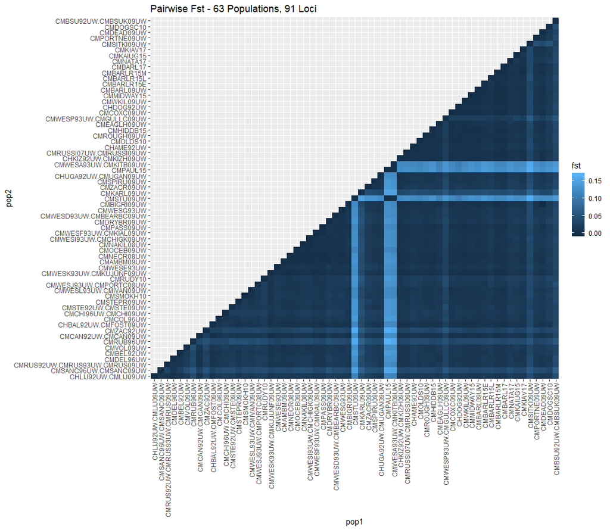

```r
get_lower_tri <- function(mat) {
  mat[upper.tri(mat)] <- NA
  return(mat)
}
pairwise_fst <- get_lower_tri(Fst_tree_populations_63_loci91$PairwiseFst) %>%
  as_tibble(rownames = "pop1") %>%
  mutate(pop1 = factor(pop1, populations_63)) %>%
  gather(pop2, fst, -pop1, na.rm = TRUE, factor_key = TRUE)
pairwise_fst %>%
  ggplot(aes(x = pop1, y = pop2, fill = fst)) +
  geom_tile() +
  theme(axis.text.x = element_text(angle = 90, vjust = 0.5, hjust = 1)) +
  ggtitle("Pairwise Fst - 63 Populations, 91 Loci")
```